# Optimal Treatment Assignment Designs for Spatial Cluster Randomized Trials

Simulation Study — Project Summary

Author

Andrew Walther

Published

September 24, 2026

# 1 Executive Summary

This report summarizes a completed simulation study that systematically compares eight treatment assignment strategies for Spatial Cluster Randomized Trials (CRTs). The study generated 12,800 scenarios by sweeping the direct treatment effect ($\tau$) and spatial DGP parameters across realistic ranges, using Maximum Likelihood Estimation (MLE) to evaluate each design (results from the revised simulation of September 2026). This summary uses the 10,240 Spatial and Poisson incidence scenarios. Queen contiguity is the primary neighbor structure and rook a sensitivity analysis; tables and figures pool the two unless labeled otherwise. The Checkerboard design is labeled “Block Stratified” in the code-generated tables and figures. Key findings:

- **Saturation Quadrants and Incidence-Guided Saturation Quadrants have the lowest MSE** and are statistically indistinguishable from each other. At the primary effect size ($\tau = 1.0$) under queen contiguity, both achieve MSE = 0.090, about **twelve times lower** than the worst-performing Checkerboard design (MSE = 1.086). Pooled over rook and queen, their MSEs are 0.080 and 0.081, versus 0.783 for Checkerboard.
- **Spatial separation is counterproductive.** Checkerboard, which alternates treated and control clusters, has the largest MSE. Under rook contiguity its treatment effect is not identified ($\mathbf{WZ} = \mathbf{1} - \mathbf{Z}$), so its estimates are biased by about $-\gamma$ and its 95% intervals cover the true effect only 15% of the time; under queen its coverage is near nominal (0.94) but its estimates are very variable. Pooled over rook and queen, its coverage is 55%.
- **Saturation-based designs are robust.** Both saturation designs are in the top statistical group at every tested level of spatial autocorrelation ($\rho$) and spillover magnitude ($\gamma$), under both spillover directions, and under both contiguity types. Under bidirectional spillover and under rook contiguity, Balanced Quartiles and Balanced Halves join that top group.
- **Coverage and power are strong for recommended designs.** MLE achieves approximately 94% coverage for every design except Checkerboard under rook, across the full effect size range ($\tau \in \{0.8, 1.0, 1.5, 2.0, 3.0\}$). Coverage therefore does not separate the designs; MSE and power do.
- **Path forward:** These results motivate applying Saturation Quadrants and Incidence-Guided Saturation Quadrants to real-world NC county-level Sudden Unexpected Death (SUD) data, where spatial dependence in outcomes is well-established and design choice carries substantial practical consequence.

# 2 Background and Motivation

## 2.1 What Is a Spatial CRT?

A Cluster Randomized Trial (CRT) assigns treatment at the level of groups — called clusters — rather than individuals. In a **spatial CRT**, clusters are geographically defined units (e.g., counties, census tracts, health districts), and outcomes may exhibit two forms of spatial structure:

1. **Spatial autocorrelation:** Nearby clusters tend to have similar outcomes, independent of treatment, due to shared socioeconomic conditions, demographics, or infrastructure.
2. **Spillover (interference):** Treatment applied to one cluster can affect outcomes in neighboring clusters — for example, when an intervention reduces disease transmission or shifts behavior across geographic boundaries.

Standard CRT analysis assumes clusters are exchangeable and independent. When spatial structure is present, this assumption fails: a poorly chosen design can create systematic bias and grossly miscalibrated confidence intervals, even when estimation is carried out with a sophisticated spatial model.

## 2.2 Application Context

This project is motivated by evaluating interventions targeting **Sudden Unexpected Death (SUD)** in North Carolina counties. SUD incidence in NC follows a Poisson process with a base rate of approximately 35 events per 100,000 person-years (Mirzaei et al.), and outcomes across neighboring counties are plausibly correlated through shared risk factors and service networks.

Selecting a treatment assignment design that accounts for this spatial structure is critical. As shown below, choosing the wrong design — even when paired with a correct spatial estimator — can inflate the mean squared error of the treatment effect estimate by a factor of ten.

## 2.3 Why Eight Designs?

Several intuitive strategies exist for assigning treatment in a spatial CRT: concentrate treatment in high-burden areas, separate treated and control clusters as widely as possible, randomize within geographic blocks, or vary treatment saturation across spatial regions. This study systematically compares eight such strategies under a common, realistic data-generating process, providing an empirical basis for principled design selection.

# 3 Methods

## 3.1 Study Region and Spatial Structure

The simulated study region is a **10×10 regular lattice** of 100 clusters. Spatial adjacency is defined by either rook contiguity (shared edges; 4 neighbors per interior cluster) or queen contiguity (shared edges or corners; 8 neighbors per interior cluster), yielding a row-standardized spatial weight matrix $\mathbf{W}$. Queen contiguity is the primary structure and rook is a sensitivity analysis. The top of the design ranking is similar under both; the main difference is that under rook the Checkerboard design makes $\mathbf{WZ} = \mathbf{1} - \mathbf{Z}$, so its treatment effect is not identified (those estimates are kept but flagged).

## 3.2 Outcome Data Generating Process

Outcomes are generated by a **Spatial Durbin Model (SDM)**:

$$\mathbf{Y} = \tau \mathbf{Z} + \gamma \mathbf{W}\mathbf{Z} + \beta \mathbf{X} + \rho \mathbf{W}\mathbf{Y} + \boldsymbol{\varepsilon}$$

Each term is defined in Table 1. The term $\gamma\mathbf{WZ}$ captures **average treatment intensity among neighbors** — the mechanism by which treatment spills over into adjacent clusters. The term $\rho\mathbf{WY}$ induces spatial autocorrelation in the outcome itself, independent of treatment.

Table 1: SDM parameter definitions.

| Symbol | Definition |
| --- | --- |
| Y | \(N \times 1\) vector of cluster outcomes |
| \(\tau\) | Direct treatment effect (estimand of interest) |
| Z | \(N \times 1\) binary treatment assignment vector |
| \(\gamma\) | Spillover coefficient — effect of neighbors' treatment on own outcome |
| W | \(N \times N\) row-standardized spatial weight matrix |
| \(\beta\) | Incidence loading coefficient (fixed at 1.0) |
| X | \(N \times 1\) baseline incidence vector |
| \(\rho\) | Outcome spatial autocorrelation |
| \(\varepsilon\) | \(N \times 1\) i.i.d. residuals, \(\varepsilon_i \sim N(0, \sigma^2)\) |

**Baseline incidence** ($\mathbf{X}$) is generated under two modes, representing realistic outcome distributions:

- *Spatial:* Uniform marginal values with spatial autocorrelation ($\rho_X \in \{0.20, 0.50\}$)
- *Poisson:* Count-based SUD-realistic incidence ($\lambda = 35/100{,}000$, 100,000 people per cluster, $\rho_X \in \{0.20, 0.50\}$)

For each incidence configuration, 10 incidence surfaces are drawn. Each design is drawn from a surface, and the outcome and the analysis use that same surface.

The full parameter sweep covers **12,800 scenarios**; the four Spatial and Poisson configurations used here account for 10,240 of them (the rest are iid incidence), as summarized in Table 2.

Table 2: Simulation parameter grid. Each combination of the five swept parameters was fully crossed with 2 neighbor types and 8 designs, yielding 10,240 Spatial and Poisson scenarios (12,800 including iid incidence).

| Parameter | Values | Levels |
| --- | --- | --- |
| Direct treatment effect (τ) | 0.8, 1.0, 1.5, 2.0, 3.0 | 5 |
| Outcome spatial autocorrelation (ρ) | 0.00, 0.01, 0.20, 0.50 | 4 |
| Spillover magnitude (γ) | 0.5, 0.6, 0.7, 0.8 | 4 |
| Spillover direction | Control only; both directions | 2 |
| Incidence config (mode × ρ_X) | Spatial × {0.20, 0.50}; Poisson × {0.20, 0.50} | 4 |

## 3.3 The Eight Treatment Assignment Designs

Table 3: The eight treatment assignment strategies evaluated, grouped by conceptual design type. The ID column shows simulation indices; display order reflects conceptual grouping (Blocking → Stratified → Saturation) rather than ID order. All designs treat exactly 50 of 100 clusters except Isolation Buffer (about 22 under queen and 38 under rook contiguity). Ties in incidence are broken at random for every design draw. Checkerboard is the only deterministic design.

| ID | Name | Description | Det. |
| --- | --- | --- | --- |
| 1 | Checkerboard | Alternating grid cells — maximizes spatial separation between treated and control | Yes |
| 5 | 2x2 Blocking | 1:1 randomization within non-overlapping 2x2 spatial blocks | No |
| 4 | Isolation Buffer | Greedy assignment: no two treated clusters share a border | No |
| 2 | High Incidence Focus | Treats the top 50 clusters by baseline incidence rank (ties broken at random) | No |
| 7 | Balanced Halves | 2-strata median split; balanced 1:1 assignment within each half | No |
| 6 | Balanced Quartiles | Stratified randomization within incidence quartile strata (exactly 50 treated) | No |
| 3 | Saturation Quadrants | Randomizes saturation rate (20-80%) independently within each geographic quadrant | No |
| 8 | Incidence-Guided Saturation Quadrants | Quadrant saturation rates guided by average incidence rank per quadrant | No |

The figure below shows all eight designs applied to the same 10×10 grid instance, with cluster color indicating baseline incidence and within-quadrant saturation percentages annotated for Saturation Quadrants and Incidence-Guided Saturation Quadrants.

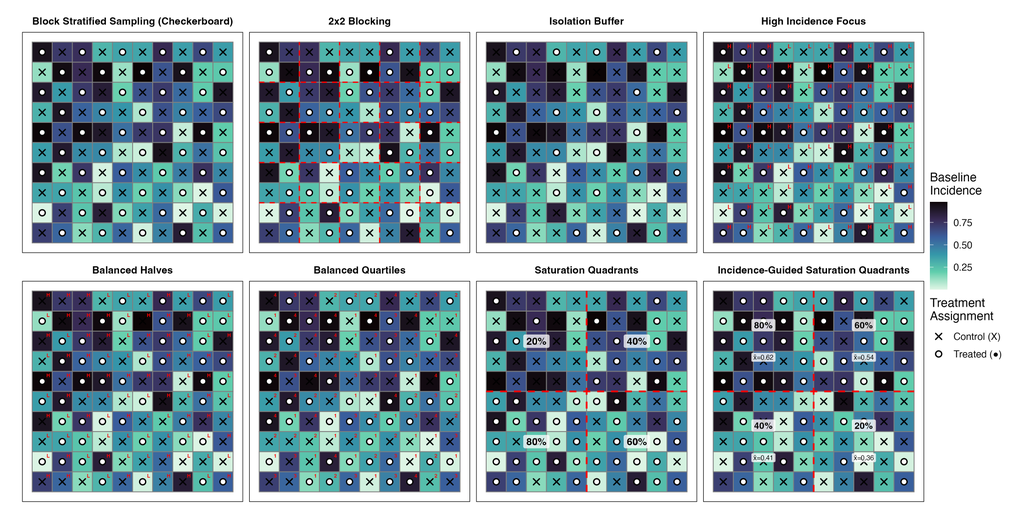

Figure 1: All eight treatment assignment designs on a common 10x10 grid, grouped by conceptual type. Cell shading indicates baseline incidence; filled circles are treated clusters, X marks are control. Saturation percentages indicate the fraction of clusters treated within each geographic quadrant for Saturation Quadrants and Incidence-Guided Saturation Quadrants; mean quadrant incidence (x-bar) is also shown for the latter.

The conceptual contrast across designs is important: Checkerboard enforces **maximum spatial separation** between treated and control clusters. Saturation Quadrants and Incidence-Guided Saturation Quadrants take the opposite approach — they vary **saturation intensity** within spatial regions, intentionally mixing treated and control units at a local level. This distinction directly determines how well each design accommodates spatial spillover in the outcome DGP.

## 3.4 Estimation and Evaluation Metrics

All results use **Maximum Likelihood Estimation (MLE)** of the spatial lag model via the project’s `fit_sar_lag()` engine, which is the same estimator as `lagsarlm` from the `spatialreg` package (agreement to about $10^{-7}$). The model is fit as an oracle — the true spillover term (the regime-specific $\gamma\mathbf{WZ}$ covariate) is included, so MLE has access to the correct spillover structure; a non-oracle model without it was also run as a sensitivity analysis and is not shown here. Each scenario uses 10 incidence surfaces × 25 design draws = **250 fits**, each with its own noise draw; Monte Carlo standard errors are computed from the 10 surface-level results.

Four metrics are tracked per scenario:

$$\text{Bias} = \mathbb{E}[\hat{\tau}] - \tau \qquad
\text{MSE} = \text{Bias}^2 + \text{Var}(\hat{\tau}) \qquad
\text{Coverage} = \mathbb{P}\!\left(\tau \in \widehat{\mathrm{CI}}_{95\%}\right) \qquad
\text{Power} = \mathbb{P}(\text{reject } H_0\!:\tau = 0)$$

MSE is the primary criterion for design comparison. Coverage provides an inference diagnostic — a well-designed trial should achieve approximately 95% coverage regardless of the true effect size.

# 4 Results

## 4.1 Overall Design Performance

Table 4 summarizes design performance at the primary effect size ($\tau = 1.0$), averaged across all four Spatial and Poisson incidence configurations and **pooled over rook and queen**. Under queen alone the MSEs are 0.090 (Saturation Quadrants), 0.090 (Incidence-Guided Saturation Quadrants) and 1.086 (Checkerboard); under rook they are 0.070, 0.072 and 0.480.

Table 4: Mean MSE and coverage at the primary effect size (tau = 1.0), averaged across Spatial and Poisson incidence configurations, rook and queen pooled. Designs are sorted by MSE (best to worst). Block Stratified = Checkerboard; its pooled coverage mixes queen (0.94) with rook (0.15), where its treatment effect is not identified.

| Design | Mean MSE | Mean Coverage | Mean Power |
| --- | --- | --- | --- |
| Sat. Quadrants | 0.080 | 0.939 | 0.947 |
| Incidence Sat. Quad. | 0.081 | 0.939 | 0.947 |
| Bal. Halves | 0.107 | 0.938 | 0.872 |
| Bal. Quartiles | 0.108 | 0.937 | 0.872 |
| Iso. Buffer | 0.147 | 0.939 | 0.767 |
| 2x2 Blocking | 0.225 | 0.938 | 0.731 |
| Hi-Inc. Focus | 0.226 | 0.938 | 0.628 |
| Block Stratified | 0.783 | 0.545 | 0.480 |

**Note**

**Note for manuscript development:** Saturation Quadrants and Incidence-Guided Saturation Quadrants perform similarly (pooled MSE 0.080 vs. 0.081 at τ = 1.0), as do Balanced Quartiles and Balanced Halves (0.108 vs. 0.107). For final manuscript reporting, one member of each pair is retained as the representative design (Incidence-Guided Saturation Quadrants and Balanced Quartiles; see `results/six_design_manuscript/`).

Saturation Quadrants and Incidence-Guided Saturation Quadrants are the top performers by a substantial margin; Checkerboard is dramatically inferior. To understand *why*, Figure 2 decomposes each design’s MSE into its squared bias and variance components for the most SUD-realistic configuration (Poisson incidence, $\rho_X = 0.20$).

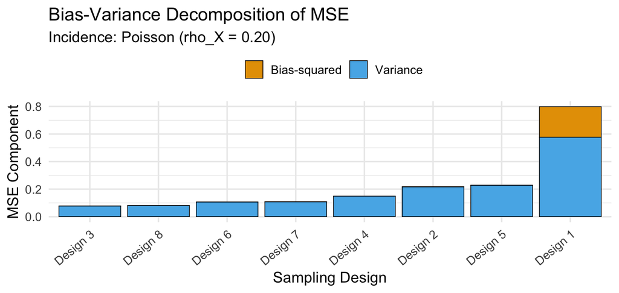

Figure 2: Bias-squared and variance contributions to MSE for each design (Poisson incidence, rho_X = 0.20, tau = 1.0, rook and queen pooled). Checkerboard (Block Stratified) has both a large variance (from queen) and a large squared bias (from rook, where its treatment effect is not identified); every other design’s MSE is almost entirely variance. Saturation Quadrants and Incidence-Guided Saturation Quadrants achieve low bias and low variance simultaneously.

Checkerboard fails because its rigid alternating structure ties treatment assignment ($\mathbf{Z}$) to average neighbor treatment ($\mathbf{WZ}$). Under rook contiguity the tie is exact ($\mathbf{WZ} = \mathbf{1} - \mathbf{Z}$): the spillover covariate is aliased and dropped, and the direct effect is not identified apart from spillover (bias about $-\gamma$). Under queen contiguity with control-only spillover the spillover covariate is nearly collinear with $\mathbf{Z}$, so MLE cannot disentangle the direct effect from spillover and the estimates are very variable. Isolation Buffer, whose greedy no-adjacency constraint treats only about 22 (queen) or 38 (rook) clusters, has intermediate MSE.

Saturation Quadrants and Incidence-Guided Saturation Quadrants succeed precisely because their saturation-based approach distributes treated and control clusters heterogeneously within each quadrant, preserving contrast between $\mathbf{Z}$ and $\mathbf{WZ}$ and keeping both bias and variance low.

## 4.2 Formal Statistical Comparisons

A **Friedman test** — the non-parametric analogue of a repeated-measures ANOVA, with each parameter combination treated as a block — confirms that design differences are highly significant: pooled over rook and queen, $\chi^2(7) = 1259.58$ over 256 blocks, $p < 2.2 \times 10^{-16}$ (queen alone: $\chi^2(7) = 570.70$, 128 blocks). This finding is not specific to any particular parameter setting: stratifying the analysis by $\rho$, $\gamma$, spillover direction, neighbor type, or incidence mode produces statistically significant design differences in every stratum (all conditional Friedman $p < 2.2 \times 10^{-16}$). The strata share incidence surfaces and noise draws, so they are not independent confirmations.

Post-hoc Nemenyi pairwise comparisons (Figure 3, Figure 4; rook and queen pooled) reveal a **four-tier structure** among designs. Saturation Quadrants and Incidence-Guided Saturation Quadrants form a **statistically distinct top tier** — not significantly different from each other (Nemenyi $p = 0.99$) and significantly different from all other designs ($p < 0.05$). Below them, Balanced Quartiles and Balanced Halves form a statistically equivalent second tier. Isolation Buffer and 2×2 Blocking form a third tier, equivalent to each other ($p = 0.13$) but significantly worse than the second tier. High Incidence Focus and Checkerboard form the bottom tier ($p = 0.32$). Under queen alone, Checkerboard, High Incidence Focus and 2×2 Blocking are not significantly different from one another; under rook alone, Balanced Quartiles and Balanced Halves are not significantly different from the saturation designs, and Checkerboard is last in nearly every block (average rank 7.98 of 8).

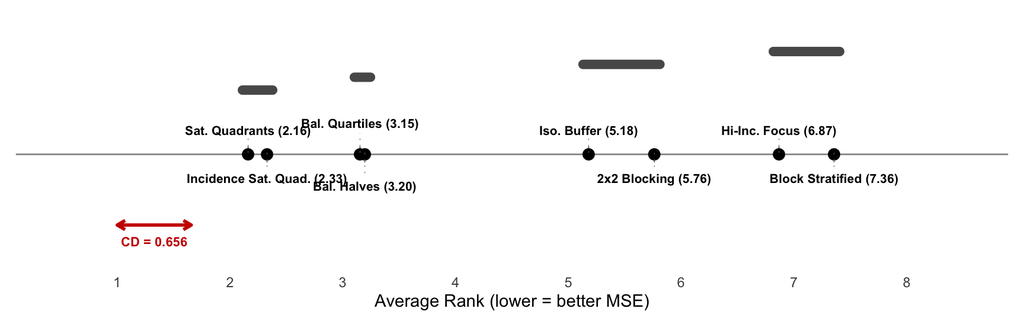

Figure 3: Critical difference (CD) diagram by average rank ($\tau = 1.0$, all Spatial and Poisson incidence configurations). Designs are positioned by their average Friedman rank (lower = better). The red arrow marks the critical difference ($CD = 0.656$): designs whose average ranks differ by less than this threshold are connected by a bold segment and are not significantly different (Nemenyi, $\alpha = 0.05$). Rook and queen pooled. Four tiers are visible: Saturation Quadrants and Incidence-Guided Saturation Quadrants (top); Balanced Quartiles and Balanced Halves (second); Isolation Buffer and 2×2 Blocking (third); High Incidence Focus and Checkerboard (Block Stratified; bottom).

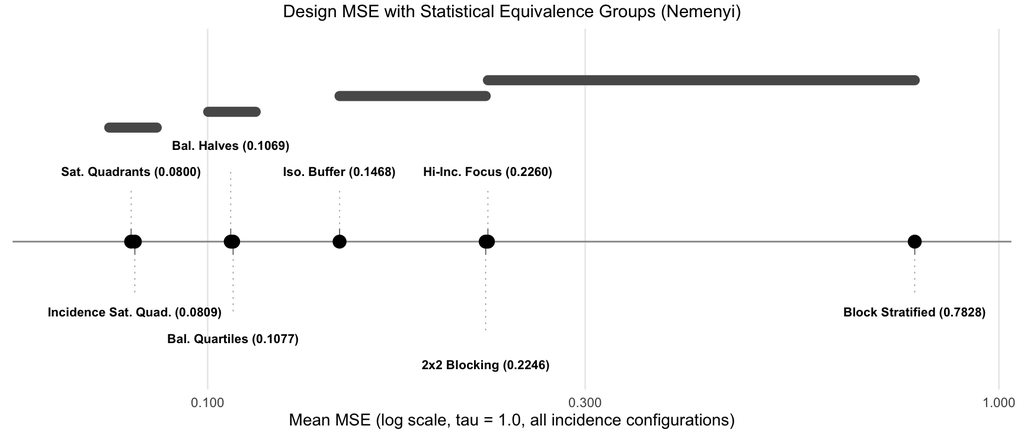

Figure 4: CD diagram by mean MSE ($\tau = 1.0$, all Spatial and Poisson incidence configurations, rook and queen pooled). Each point shows a design’s mean MSE on a log scale; designs are sorted left-to-right by increasing MSE. Horizontal bars connect designs that are not significantly different from each other (Nemenyi, $\alpha = 0.05$). This view conveys the practical magnitude of MSE differences alongside the statistical grouping. The four-tier structure from Figure 3 is preserved: the saturation designs achieve the lowest MSE and are clearly separated from all others.

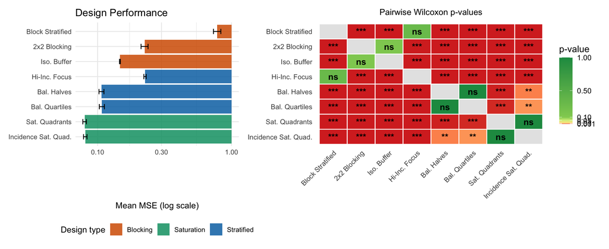

## 4.3 Sensitivity to Spatial Conditions

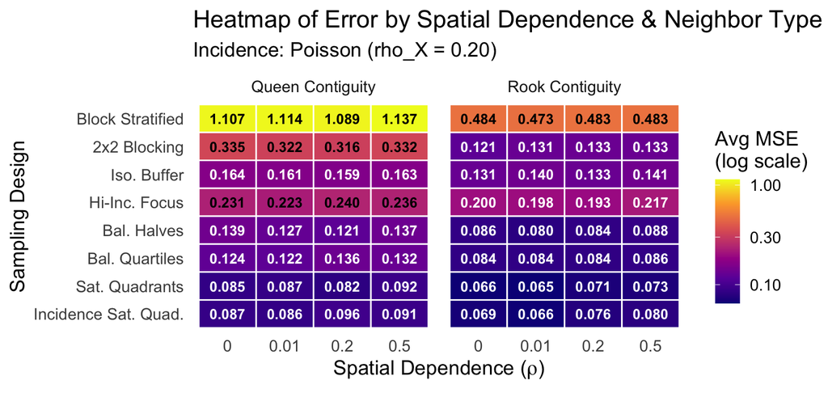

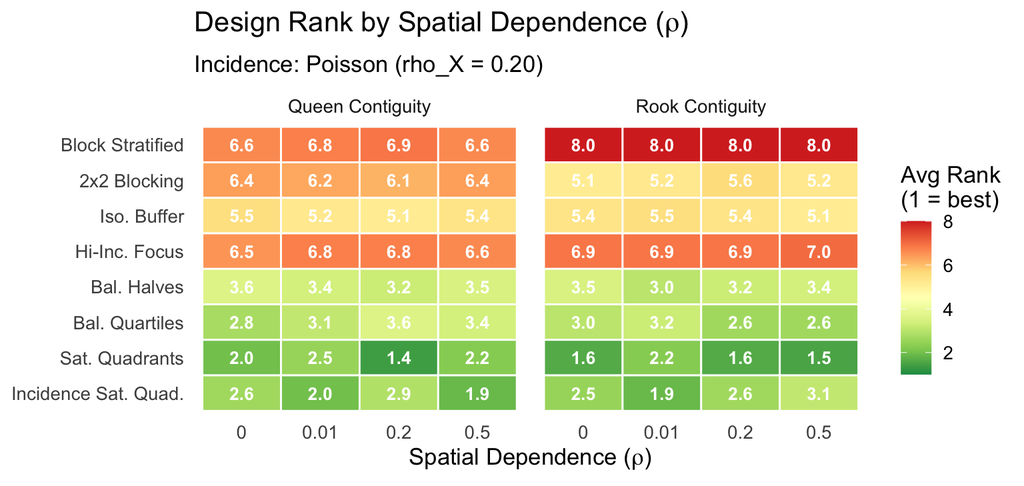

Figure 7: Design rank by outcome spatial autocorrelation (rho), Poisson incidence (rho_X = 0.20, tau = 1.0). Each cell shows the average rank of that design across gamma and spillover direction scenarios at the given rho level (rank 1 = lowest MSE = best). Green indicates top-ranked designs; red indicates the worst. Saturation Quadrants and Incidence-Guided Saturation Quadrants rank at or near the top throughout; Checkerboard (Block Stratified) ranks last at every rho under rook, where its treatment effect is not identified, and is near the bottom with High Incidence Focus and 2x2 Blocking under queen.

**Outcome spatial autocorrelation ($\rho$)** and **spillover magnitude ($\gamma$)** change absolute MSE only modestly for most designs (Figure 6, Figure 7); the main exception is Checkerboard, whose pooled MSE rises from 0.70 at $\gamma = 0.5$ to 0.88 at $\gamma = 0.8$. Neither parameter changes which designs are at the top, and the saturation designs’ MSE advantage over the stratified and blocking designs is about the same at every level of $\gamma$ (rook and queen pooled).

Two parameters change the rankings only in part:

- **Spillover direction** (`control_only` vs. `both`): under control-only spillover the top group is the two saturation designs alone; under bidirectional spillover Balanced Quartiles ranks first, with Balanced Halves and both saturation designs statistically tied with it (all conditional Friedman $p < 2.2 \times 10^{-16}$ in both strata; rook and queen pooled).
- **Neighbor type** (rook vs. queen): queen contiguity yields higher absolute MSE for every design (e.g., Saturation Quadrants 0.090 under queen vs. 0.070 under rook). The top of the ranking is similar; under rook the top group widens to include Balanced Quartiles and Balanced Halves, and Checkerboard’s treatment effect is not identified.

## 4.4 Effect Size Sensitivity and Statistical Power

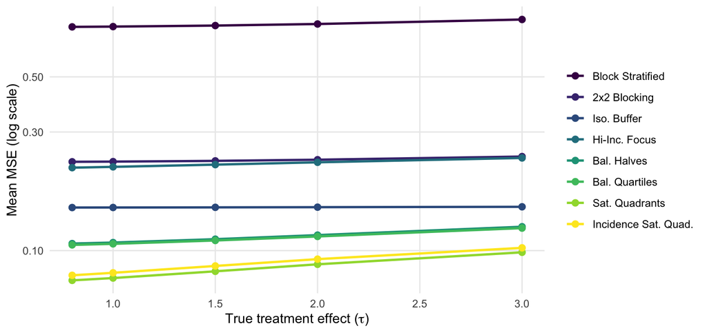

Figure 8: Mean MSE by design across effect sizes (tau in {0.8, 1.0, 1.5, 2.0, 3.0}), Poisson incidence (rho_X = 0.20), rook and queen pooled, log scale. MSE rises slightly with tau for every design, and the design ordering is the same at every tau; Saturation Quadrants and Incidence-Guided Saturation Quadrants maintain the lowest MSE across the full range and Checkerboard (Block Stratified) the highest.

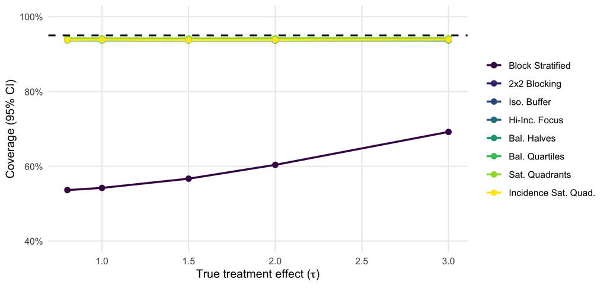

Figure 9: Coverage of 95% confidence intervals by design across effect sizes, Poisson incidence (rho_X = 0.20), rook and queen pooled. The dashed line marks nominal 95% coverage. All designs except Checkerboard (Block Stratified) maintain near-nominal coverage throughout; Checkerboard’s pooled coverage (54% at tau = 0.8 to 69% at tau = 3.0) comes entirely from rook, where its treatment effect is not identified; under queen it is 94% at every tau.

Design rankings are **stable across the full effect size range** (Figure 8): MSE rises slightly with $\tau$ for every design, and the ordering of designs is the same at every $\tau$. Each $\tau$ reuses the same design and noise draws, so the $\tau$ levels are not independent confirmations of one another.

Coverage (Figure 9) tells a particularly striking story. All designs except Checkerboard maintain approximately 94% coverage under MLE across all tested effect sizes (about one point below nominal, a finite-sample property of the Wald interval). **Checkerboard’s pooled coverage is 54–69%**, and all of that shortfall comes from rook contiguity (13–44% across $\tau$), where $\mathbf{WZ} = \mathbf{1} - \mathbf{Z}$ and the direct effect is not identified apart from spillover. This is not simply a power deficit — it is a structural failure of the alternating assignment pattern. Under queen, Checkerboard’s coverage is 94%, but its MSE is the largest of any design.

# 5 Design Recommendations and Next Steps

## 5.1 Recommended Designs

**Incidence-Guided Saturation Quadrants** and **Saturation Quadrants** are the recommended designs. They are statistically indistinguishable (MSE 0.090 for both under queen at $\tau = 1.0$; pooled 0.081 vs. 0.080, within Monte Carlo standard error), so the data do not favor one over the other. Incidence-Guided Saturation Quadrants sets quadrant-level saturation rates by the incidence rank of each region; Saturation Quadrants randomizes saturation rates across quadrants and does not require incidence data, which makes it simpler to implement and explain to stakeholders.

**Checkerboard should never be used** when spatial spillover is anticipated. Its intuitive appeal — spatially separating treated and control units — is precisely what makes it fail in the presence of spillover. Both saturation designs should be preferred over the blocking and stratified designs (2×2 Blocking, Isolation Buffer, High Incidence Focus, Balanced Halves, Balanced Quartiles) in the SUD application context, where spillover across county lines is plausible.

## 5.2 Open Questions and Path to Real-World Application

These simulation results establish the theoretical case for saturation-based designs under a regular lattice with uniform cluster populations. The next phase of this work will apply these findings to **non-regular NC county census tract geometries**, raising several methodological questions for the upcoming collaborator meeting:

1. **Spatial weight matrix for irregular polygons:** How should adjacency be defined when clusters are irregular county tracts? Queen contiguity (shared border of any nonzero length) is the natural extension; alternative definitions (distance-based, shared border length-weighted) warrant consideration.
2. **Generalizing the quadrant partition:** Saturation Quadrants and Incidence-Guided Saturation Quadrants rely on rectangular geographic quadrants. For a non-rectangular study region like NC, analogous spatial partitions — k-means geographic clusters, administrative regions, or compass quadrant approximations — would need to replace the regular grid structure.
3. **Relaxing the oracle MLE assumption:** The primary estimator uses the true spillover term as a covariate. In practice, the spillover structure must be assumed or estimated. A non-oracle model that omits the spillover term ($Y \sim Z + X$) has been run on the same simulated outcomes as a sensitivity analysis (not summarized here); approximated spillover terms remain to be studied before applying these methods to real data.
4. **Heterogeneous cluster populations:** NC counties vary substantially in population size, which affects expected Poisson event counts per cluster. The current study assumes equal cluster populations ($n = 100{,}000$); variable population sizes may interact with incidence-guided design strategies in non-trivial ways.